# npi_firstpass

aj_mitchell

April 3, 2019

**This document is for explaining the pilot NPI behavior analysis.**

## Description

30 individual behaviors were included in the analysis and subsequently divided up into 4 composite groups to investigate the effects of PR. These composite groups were made based on aggregates of **anxious behaviors**, **pro-social behavior (social affiliation)**, **non-affiliative social behaviors**, and **object oriented behaviors**. These scores are outlined in later tables below.

The table below provides correlational values about the individual behaviors.

The subsequent table outlines the overall effects of protein restriction whereas the latter graphs detail specific differences of either 33% or 50% PR. I did not look at individual behavioral differences (comparing individual behaviors across diet groups). **Only pro-social behavior surrounding the 50 PR showed significant differences based on diet group.** This is visualized later in the document.

The ‘v2’ just capture the little changes that I thought improved the groups.

**Prosocial** = “Play”, “Play Face”, “Contact peer”, “Follow”, “Groom”, “Approach peer”, “Lipsmack”

**Prosocial_v2** = “Play”, “Play Face”, “Contact peer”, “Follow”, “Groom”, “Approach peer”, “Lipsmack”, “Inspect”, “Mouth peer”

**Nonsocial** = “Open Mouth Threat”, “Aggress”, “Bite”, “Displace”, “Avoid”, “Crooked Tail”,

**Nonsocial_v2** = “Open Mouth Threat”, “Aggress”, “Bite”, “Resource Takeover”, “Displace”, “Avoid”, “Crooked Tail”, “Steal Resource Attempt Count”

**Object_Oriented** = “Mouth Object”, “Touch Object”, “Manipulate Object”, “Inspect Object”, “Steal Resource Attempt”

**Anxious** = “Stereotypy”, “Scratch”, “Yawn”, “Avoid”, “Fear Grimmace”

**Omitted** = “No Response to Object”, “Contact Peer Count”, “No Response”

## Correllation Values and Matrix

|  | Var1 | Var2 | value |
| --- | --- | --- | --- |
| 1 | ZScratch | ZStereotypy | 0.0387190796555467 |
| 2 | ZYawn | ZStereotypy | -0.05 |
| 3 | ZCrook_Tail | ZStereotypy | -0.0858833812602066 |
| 4 | ZPlay | ZStereotypy | -0.05 |
| 5 | ZPlay_Face | ZStereotypy | -0.1375 |
| 6 | ZNo_Response | ZStereotypy | -0.33839277667363 |
| 7 | ZLipsmack | ZStereotypy | -0.0716335438008347 |
| 8 | ZInspect | ZStereotypy | -0.100984009401775 |
| 9 | ZMouth_peer | ZStereotypy | 0.191761389975766 |
| 10 | ZContact_peer | ZStereotypy | 0.469029977593676 |

[output cut: 860 more lines]

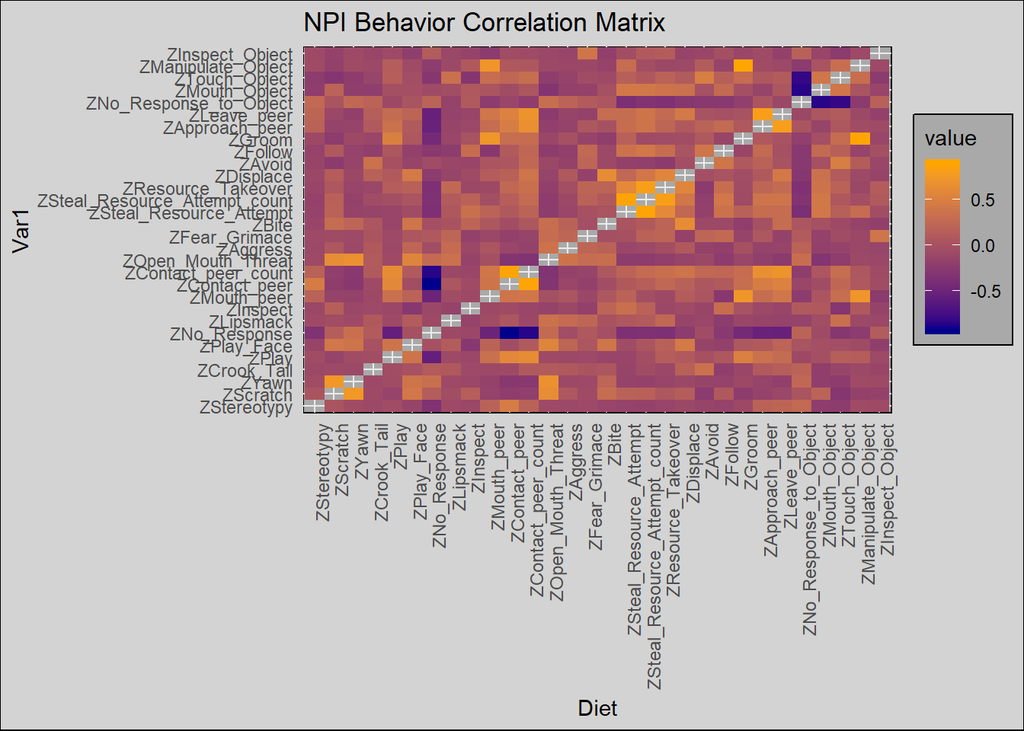

the table below is the output when you control for housing. After speaking with Jacqui, she said that several animals in year 2 were housed differently than the others. Thus, i removed these animals to look at the **effect housing has on the beahvioral outcome**.

Take this data with a grain of salt though.. at this point, a lot of manipulation have been made and i will likely need to reevaluate this part of the analysis. Additionally, it has not been looked at as thoroughly as other measurements.

The boxplot below is for fact checking the distribution

|  | matched_housing_titles | matched_housing_pvals |
| --- | --- | --- |
| 1 | Prosocial Controlled Housing | 0.630528913810648 |
| 2 | Nonsocial Controlled Housing | 0.795936261880534 |
| 3 | Object Oriented Controlled Housing | 0.924095313935454 |
| 4 | Anxious Controlled Housing | 0.595035151629138 |

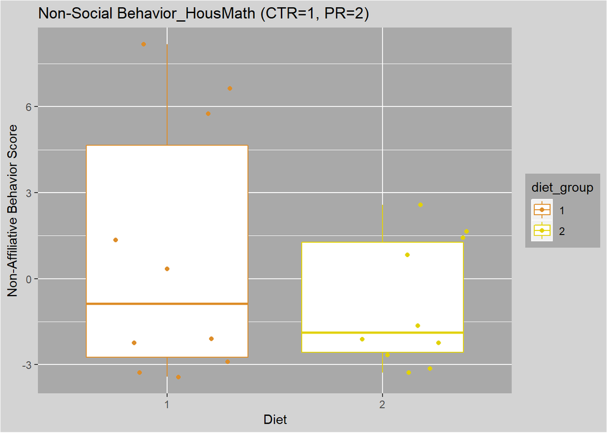

## Overall Behavioral Differences

This table details the different effects of diet based on overall year1 and year2 PR vs Control performance.

|  | pvals_NPI_titles | pvals_NPI_subjectivegroups |
| --- | --- | --- |
| 1 | Anxious Behavior | 0.501423399128389 |
| 2 | Pro-Social Behavior | 0.426167228024813 |
| 3 | Non-Social Behavior | 0.756444278116105 |
| 4 | Object Oriented Behavior | 0.901540086043225 |

## Year 1 vs Year 2 differences

The table below describes differences based on year one and year two. In summary, only year 1 displayed behavioral differences. Year 1 subjected to a PR diet were less likely to engage in prosocial behavior. Overall diet differences were not seen, also since the diet was changed between year 1 and year 2, I felt separating the years was more informative. Especially given the results.

Year 2 Information: - n = 13 - 7 CTR(1) / 6 PR(2)

Each group was subject to a Shapiro Wilks test for normality, and the respective t-test was done to calculate the p-value. For groupings whose distribution significantly deviated from the norm, a Wilcoxon/Mann-Whitney test was used.

**50per = year 1 @ 50% PR**

**33per = year 2 @ 33% PR**

|  | pvals_PRgroups_titles | pvals_PRgroups_on_behaviors |
| --- | --- | --- |
| 1 | Anxious_33per_PR | 0.471373252344597 |
| 2 | Anxious_50per_PR | 0.491127746033741 |
| 3 | Pro-Social_33per_PR | 0.835664335664336 |
| 4 | Pro-Social_33per_PR_v2 | 0.445221445221445 |
| 5 | Pro-Social_50per_PR | 0.0195110089928093 |
| 6 | Pro-Social_50per_PR_v2 | 0.13319377804557 |
| 7 | Non-Affiliative_33per_PR | 0.648337863654666 |
| 8 | Non-Affiliative_33per_PR_v2 | 0.835664335664336 |
| 9 | Non-Affiliative_50per_PR | 0.115131859891325 |
| 10 | Non-Affiliative_50per_PR_v2 | 0.060361470506588 |

[output cut: 2 more lines]

Below is the boxplot overlayed with scatter plot showing both the avg difference between groups and where each individual falls per group. **This was the only behavior category that showed significant differences based on diet.**

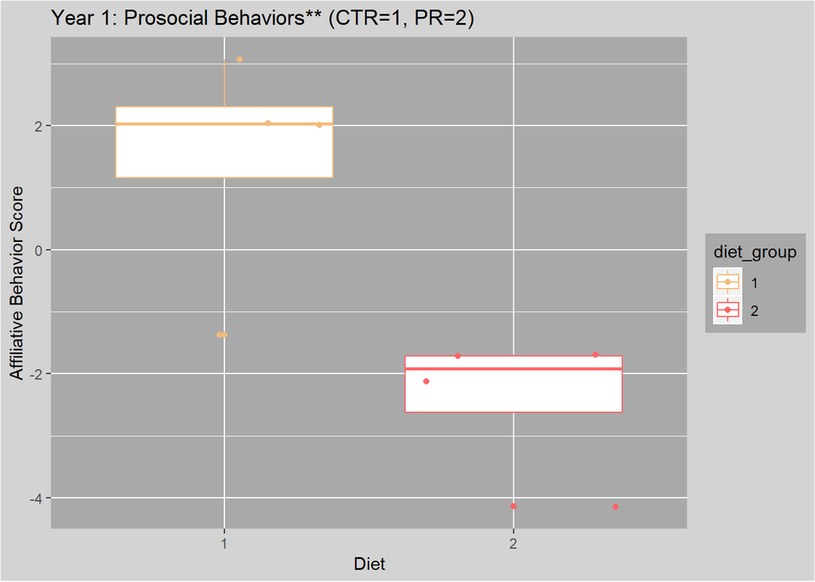

## Extra Visualizations

Here, only groups i thought were interesting are visualized; just for simplicity. We can add as many as desired.

**Non-affiliative behaviors during year 1 (50% PR) were strongly trending but not significant.**

Refer to the list in the **Description Section** for individual behaviors that make up this group.

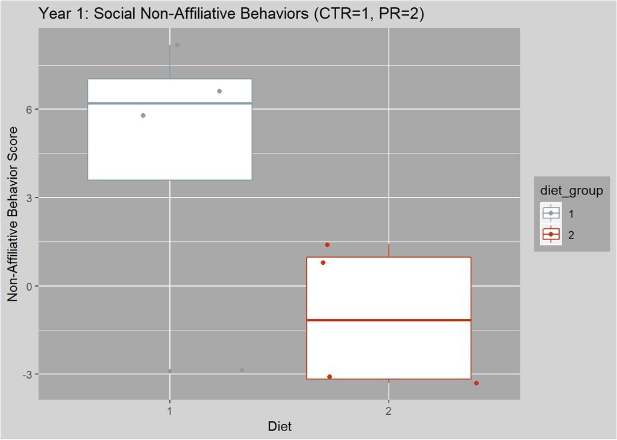

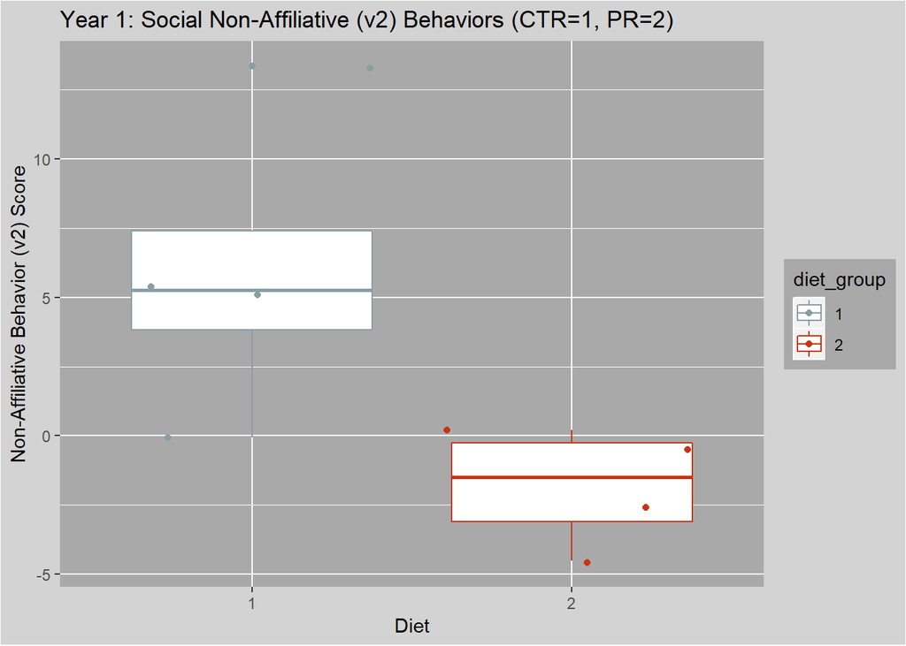

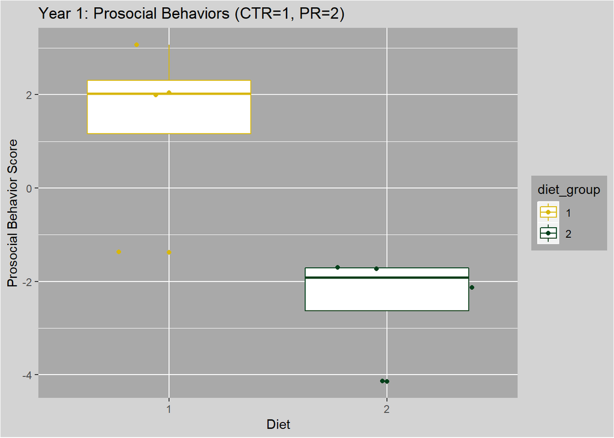

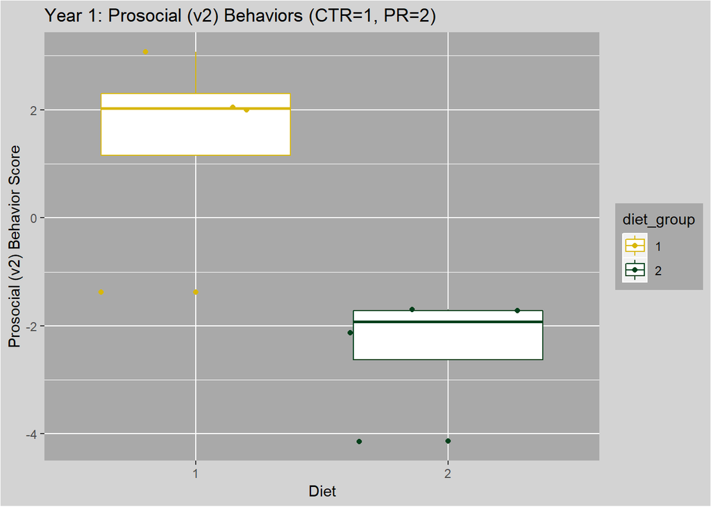

**Closing**

I’d like to talk about adjusting the groupings and how we could expand on that end. Or would these be the groups we move forward with? I thought they were useful because the interpretation of them is more simple than the community detection approach.

There are many things I need to improve on here but mainly:

- **I want to finalize and better form my groupings**
  - some of the composites were created using steal_resource_attempt rather than steal_resource_attempt_count. And i am unsure of which would be the better approach for quantifying such behaviors.
- **I plan to run an SEM analysis to look at the fit of these composites**
  - I wanted to get this to you prior to doing that so we can discuss changes/approaches to the SEMs.
- **I am open to any changes. I am unsure if the makeup of the data allows us to use Community Detection, and I also thought grouping terms into pro-social/non-social/anxious provides a better output.**
  - But again, we can adjust where needed.. this adjustment/documentation process has become increasingly faster for me.